# Phylogentic Analysis on UVRAG

Ashlee

4/27/2022

# Introduction

For my final project I will be creating a phylogenetic tree between twenty species that carry similar conservation of the promoter region of the UVRAG gene that will then be used for phylogenetic analysis. A phylogenetic tree is a branching diagram or a tree showing the evolutionary relationships among various biological species or other entities based upon similarities and differences in their physical or genetic characteristics. The UV Radiation Resistance Associated Gene (UVRAG) complements the ultraviolet sensitivity of xeroderma pigmentosum group C cells and encodes a protein with a C2 domain. The protein activates the Beclin1-PI(3)KC3 complex, promoting autophagy and suppressing the proliferation and tumorigenicity of human colon cancer cells. Chromosomal aberrations involving this gene are associated with left-right axis malformation and mutations in this gene have been associated with colon cancer.

# Libraries

```r
library(phytools) # functions for phylogenetic analysis
library(ade4) # analysis of ecological data
library(ape) # analysis of phylogenetics and evolution
library(adegenet) # exploratory analysis of genetic and genomic data
library(phangorn) # phylogenetic reconstruction and analysis
library(tidyverse) # collection of packages
library(here) # file referencing
```

# Example using influenza data

fasta2DNAbin reads in alignments in fasta format and outputs a DNAbin object. This output contains alignments or SNPs. This function is used through the ape package.

```r
dna <- fasta2DNAbin(file="http://adegenet.r-forge.r-project.org/files/usflu.fasta")
```

```
##
##  Converting FASTA alignment into a DNAbin object...
##
##
##  Finding the size of a single genome...
##
##
##  genome size is: 1,701 nucleotides
##
## ( 30  lines per genome )
##
##  Importing sequences...
## .........................................................................................................................................................................................................................................................................................................…
##  Forming final object...
##
## ...done.
```

```r
dna
```

```
## 80 DNA sequences in binary format stored in a matrix.
##
## All sequences of same length: 1701
##
## Labels:
## CY013200
## CY013781
## CY012128
## CY013613
## CY012160
## CY012272
## ...
##
## Base composition:
##     a     c     g     t
## 0.335 0.200 0.225 0.239
## (Total: 136.08 kb)
```

Read in the annotation file

```r
annot <- read.csv("http://adegenet.r-forge.r-project.org/files/usflu.annot.csv", header=TRUE, row.names=1)
annot
```

```
##    accession year                              misc
## 1   CY013200 1993       (A/New York/783/1993(H3N2))
## 2   CY013781 1993       (A/New York/802/1993(H3N2))
## 3   CY012128 1993       (A/New York/758/1993(H3N2))
## 4   CY013613 1993       (A/New York/766/1993(H3N2))
## 5   CY012160 1993       (A/New York/762/1993(H3N2))
## 6   CY012272 1994       (A/New York/729/1994(H3N2))
## 7   CY010988 1994       (A/New York/733/1994(H3N2))
## 8   CY012288 1994       (A/New York/734/1994(H3N2))
## 9   CY012568 1994       (A/New York/746/1994(H3N2))
## 10  CY013016 1994       (A/New York/750/1994(H3N2))
## 11  CY012480 1995       (A/New York/666/1995(H3N2))
## 12  CY010748 1995       (A/New York/648/1995(H3N2))
## 13  CY011528 1995       (A/New York/669/1995(H3N2))
## 14  CY017291 1995       (A/New York/681/1995(H3N2))
```

[output cut: 66 more lines]

## Using a Distance-based method phylogeny

Distance-based methods are produced calculating the genetic distances between pairs of taxa, followed by hierarchial clustering.

### Step 1

```r
D <- dist.dna(dna, model = "TN93") #TN93 type of evolutionary model being used. This one allows for different transition rates, heterogenous base frequencies, and variation of substitution rate at the same site
length(D) #number of pairwise distances, computed as n(n-1)/2
```

```
## [1] 3160
```

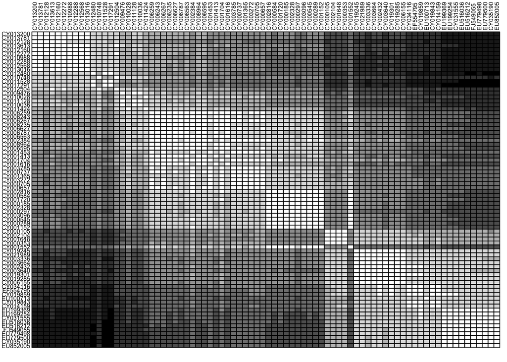

```r
temp <- as.data.frame(as.matrix(D))
table.paint(temp, cleg=0, clabel.row=.5, clabel.col=.5) #darker shades of gray mean a larger distance #
```

```r
# Shows a trend or pattern
```

### Step 2

```r
tre <- nj(D) # classic neighbor-joining algorithm
class(tre) #all trees created using {ape} package will be of class phylo
```

```
## [1] "phylo"
```

```r
tre <- ladderize(tre)
tre # tells us what the tree will look like but doesn't show the actual construction
```

```
##
## Phylogenetic tree with 80 tips and 78 internal nodes.
##
## Tip labels:
##   CY013200, CY013781, CY012128, CY013613, CY012160, CY012272, ...
##
## Unrooted; includes branch lengths.
```

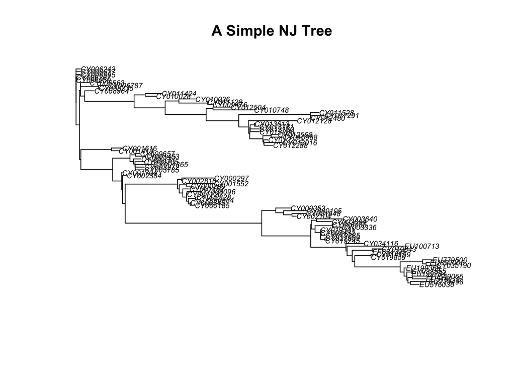

```r
plot(tre, cex = 0.6)
title("A Simple NJ Tree")
```

### Step 3

Example using a cluster diagram

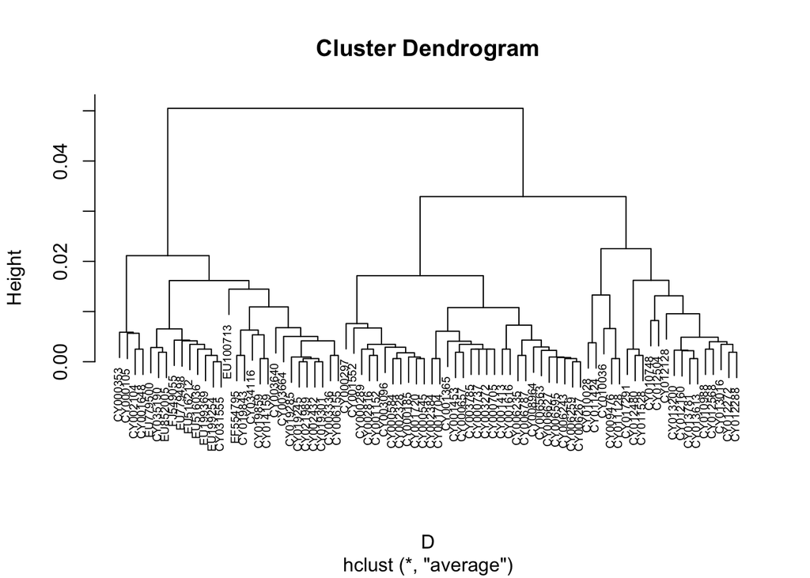

```r
# or
h_cluster <- hclust(D, method = "average", members = NULL) # method = average is used for UPGMA, members can be equal to NULL or a vector with a length of size D
plot(h_cluster, cex = 0.6)
```

# Working with UVRAG promoter region

Study whether specific Transcription Factor Binding Sites (TFBS) play a role in the regulation and expression of the promoter region.

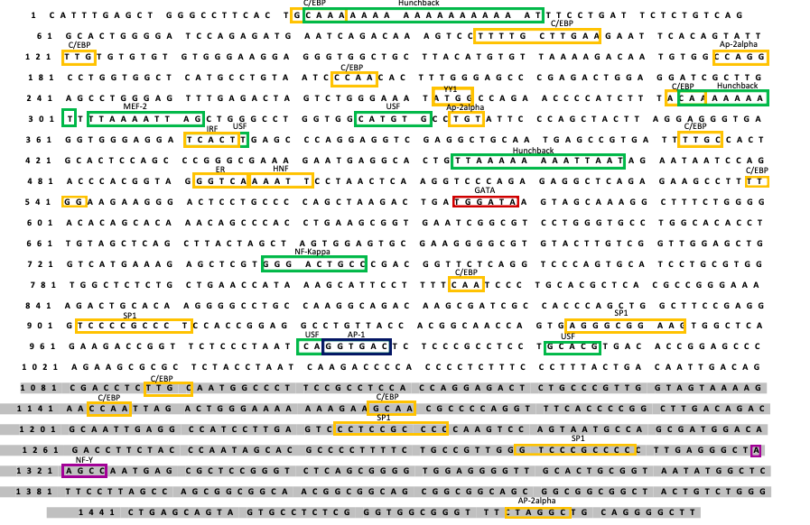

TFBS of the UVRAG Promoter

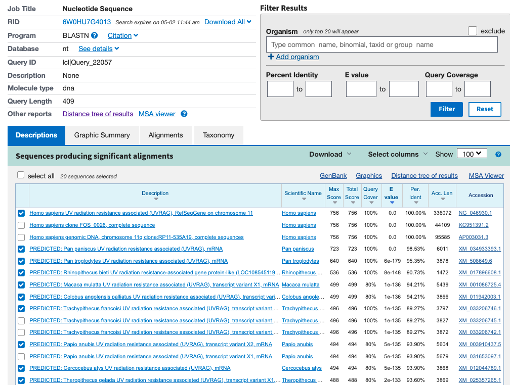

NCBI BLAST

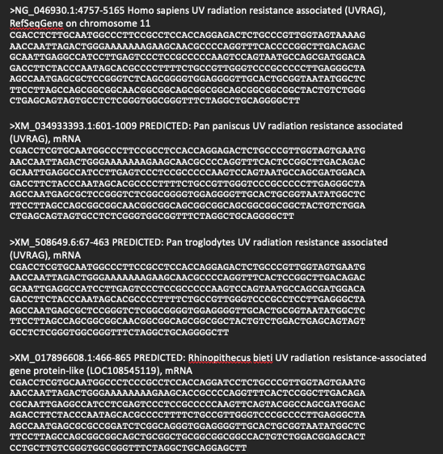

UVRAG Data

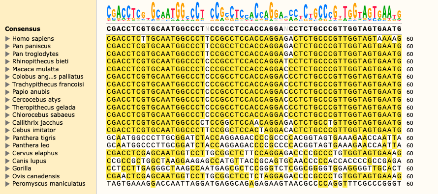

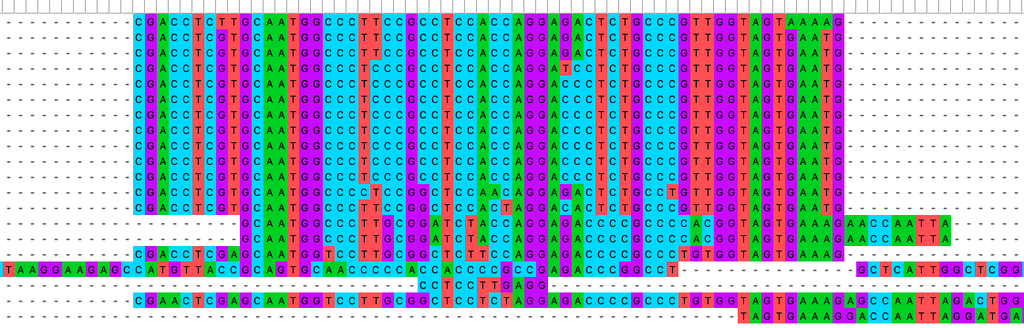

Multiple Sequence Alignments for UVRAG

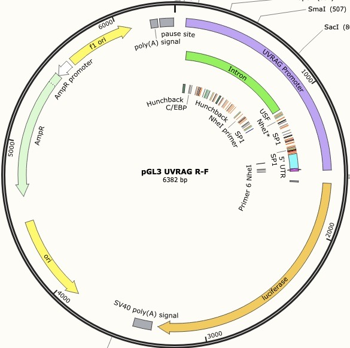

UVRAG sublconed into pGL3

```r
UVRAG1 <- fasta2DNAbin(file = here("Data", "MSAs.fas"))
```

```
##
##  Converting FASTA alignment into a DNAbin object...
##
##
##  Finding the size of a single genome...
##
##
##  genome size is: 315 nucleotides
##
## ( 2  lines per genome )
##
##  Importing sequences...
## ..............................
##  Forming final object...
##
## ...done.
```

```r
UVRAG1
```

```
## 20 DNA sequences in binary format stored in a matrix.
##
## All sequences of same length: 315
##
## Labels:
## Homo sapiens
## Pan paniscus
## Pan troglodytes
## Rhinopithecus bieti
## Macaca mulatta
## Colobus angolensis palliatus
## ...
##
## Base composition:
##     a     c     g     t
## 0.174 0.335 0.292 0.199
## (Total: 6.3 kb)
```

Creating a data frame

```r
U <- dist.dna(UVRAG1, model = "TN93")
length(U) #number of pairwise distances, computed as n(n-1)/2
```

```
## [1] 190
```

```r
temp1 <- as.data.frame(as.matrix(U))
```

## Creating a phylogenetic tree using the UVRAG promoter region

```r
# Creating tree
tree <- fastme.bal(U) # had to use fastme based off of fasta data. minimum evolution algorithm
class(tree) #all trees created using {ape} package will be of class phylo
```

```
## [1] "phylo"
```

```r
tree <- ladderize(tree)
tree # tells us what the tree will look like but doesn't show the actual construction
```

[output not shown]

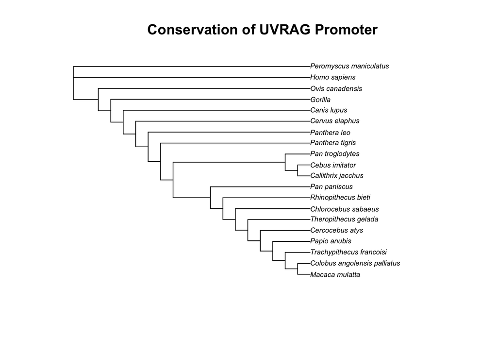

```r
plot(tree, cex = 0.6)
title("Conservation of UVRAG Promoter")
```

Homo Sapiens share similar conservation with *Peromyscus maniculatus* for this promoter region sequence. Each node depicts the similar common ancestor of the species. Although this is preliminary data and is subject to change as further research is conducted on the promoter region, it tis a good starting point leading to possible further directions when studying the putative promoter region.

#### Using the data from the UVRAG promoter to create an unrooted tree

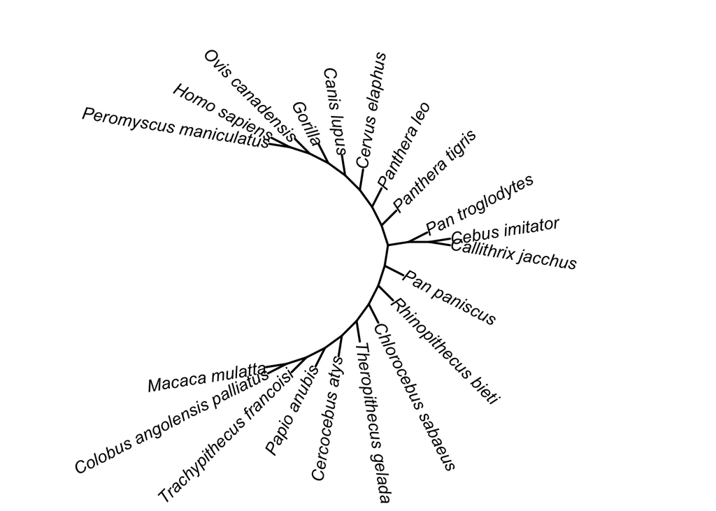

[figure not shown]

```r
plot(unroot(tree),type="unrooted",no.margin=TRUE,lab4ut="axial",
    edge.width=2)
```